# PALs

Thomas Quinn

June 1, 2017

## PALs

The remaining visualization tools all make use of the **Popular Adjacent Ligand or self** (PALs) criteria, an attempt to procedurally partition a disproportionality network into meaningful clusters. For this, we assign each node (e.g., transcript) one PAL. The PAL is defined as the adjacent node with the greatest amount of connectivity (i.e., highest degree). However, if the node itself has more connectivity than any of its partners, it is its own PAL. By counting the number of times each feature serves as a PAL to another feature, we get a measure of the “hub-ness” of a node, which we call the PAL-score. Note that we use this PAL-score instead of connectivity (i.e., degree) in order to penalize “nested hubs” whereby one node has a high connectivity with many of the same partners as another highly-connected adjoining node. Typically, we only consider the top $k$ PALs, meaning that some nodes end up with a “Missing” PAL.

Next, we assign each edge a PAL. Edges that have a top PAL as one and only one of their nodes get assigned that PAL. Edges that have top PALs as both of their nodes get assigned “Bridged”. Edges without a top PAL as one of their nodes will get assigned a PAL if either (a) both nodes have the same adjacent PAL or (b) one node has a “Missing” adjacent PAL. In the setting of relative data, we cannot compare absolute abundances: therefore, we use the PAL criteria as a simple way to group features that share a common “hub”. Although we cannot easily compare feature abundances across PAL modules (at least without an adjoining reference), we can easily compare feature abundances within a PAL module. As such, for these figures, we color pairs based on the PAL for that edge, excluding any pairs with a “Missing” or “Bridged” PAL.

We draw attention here to the `gemini` function which plots log-fold change in VLR against difference in the log-ratio means (LRM) of the count ratio relative to its PAL. This figure provides a lot of information, summarizing how the PAL modules change in coordination *and* in relative abundance between the groups. Here, an *increase* along the **y-axis** represents a relative *decrease* in proportionality in Group 1. An *increase* along the **x-axis** represents a *increase* in mean abundance of a feature relative to its PAL in Group 1.

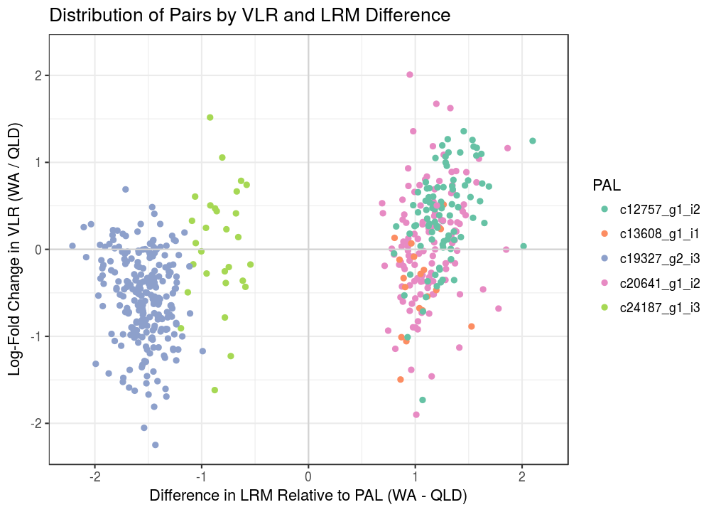

```r
gemini(pd.d, cutoff = 1000, k = 5, prompt = FALSE)
```

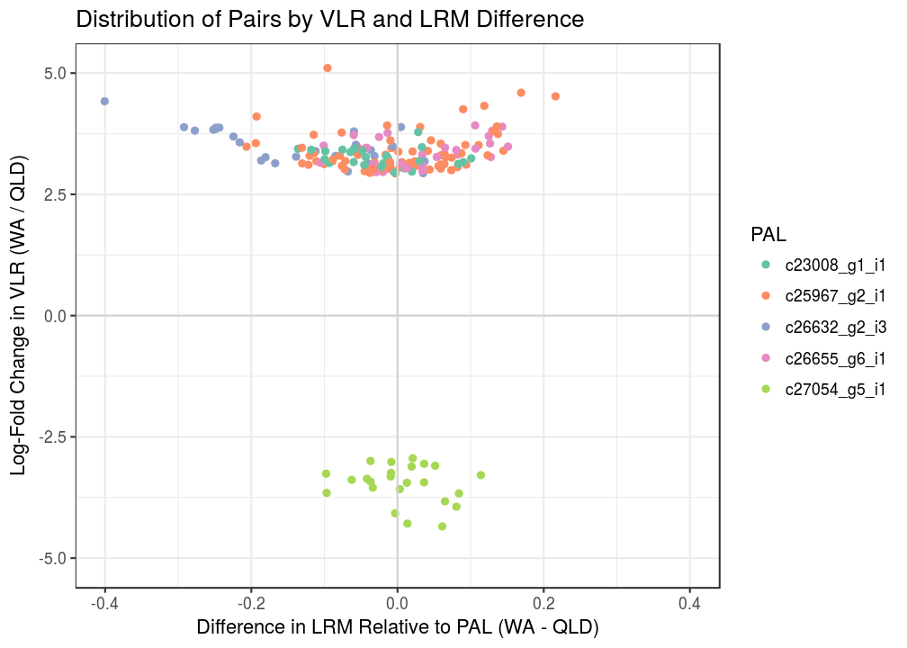

```r
gemini(pd.e, cutoff = 1000, k = 5, prompt = FALSE)
```

This figure shows that, for $\theta_d$, all features connected to a top PAL “hub” change together (i.e., in abundance) the same way relative to their PAL. This seems to occur regardless of whether there is a gain or loss of coordination between groups for that pair (although each module seems to slightly favor either gain or loss). A change in the relative abundance of the “spoke” transcripts could occur because (a) the “spokes” changed while the “hub” stayed the same, (b) the “spokes” stayed the same while the “hub” changed, (c) the “spokes” changed in one direction while the “hub” changed in another, or (d) the “spokes” changed in the same direction but by a different magnitude as compared to the “hub”. Differential proportionality analysis does not address absolute changes.

On the other hand, for $\theta_e$, all features connected to a top PAL “hub” change together (i.e., in coordination) the same way relative to their PAL. Again, this seems to occur regardless of whether there is a gain or loss in the log-ratio abundance (although each module seems to slightly favor gain or loss). We remind the reader here that a software package like `ALDEx2` uses a log-ratio transformation to estimate “absolute” changes in abundance, although its performance depends on how well the transformation approximates an unchanged reference.